# Final

Adam Guerra, Luke Todd, Riley Zamora

2023-06-11

## Problem 1

### Introduction

Understanding soil disturbance is an overlooked aspect of plant community structure (Terri). Kangaroo Rat mounds in particular cause both physical and nitrate changes in soil (Hyeong-Tae). These changes create microhabitats, house rare species for their respective areas, and cause changes in seed banks (Gao). In this analysis we are focusing on seed counts due to their importance in regards to species persistence in unpredictable environments (Terri). Specifically, how seed counts vary between different mound locations.

### Methods

#### Loading Data

```r
# loading data
kang_seed <- read.table(here("data/sev208_kratseedbank_20120213.txt"), sep=',', header = TRUE) |>
             mutate(mnd = as.factor(mnd)) |>
             filter(!(species %in% c("soil", "plant", "dist", "litter", "gravel")))
```

#### Missing Data

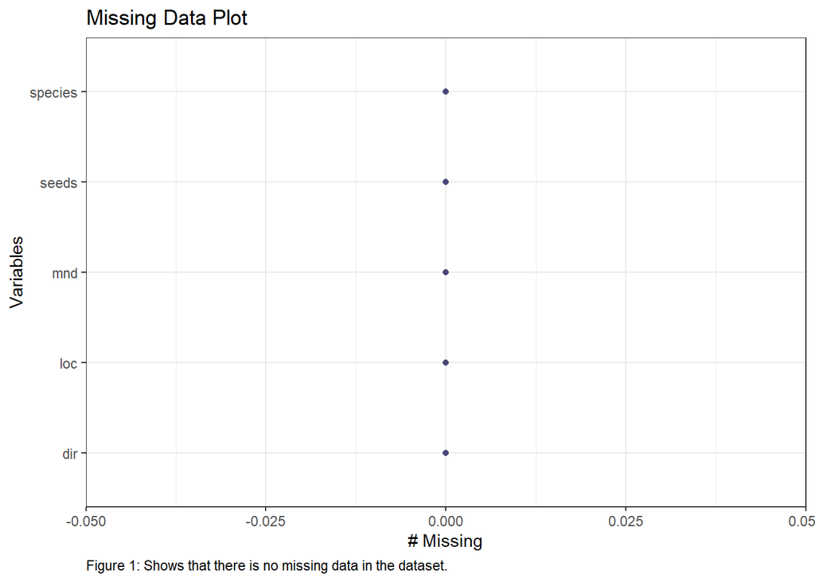

```r
gg_miss_var(kang_seed) +
  labs(caption = "Figure 1: Shows that there is no missing data in the dataset.",
       title = "Missing Data Plot") +
  theme_bw() +
  theme(plot.caption = element_text(hjust = 0))
```

#### Skim

```r
skim(kang_seed)
```

Data summary

| Name | kang_seed |
| --- | --- |
| Number of rows | 960 |
| Number of columns | 5 |
| _______________________ |  |
| Column type frequency: |  |
| character | 3 |
| factor | 1 |
| numeric | 1 |
| ________________________ |  |
| Group variables | None |

**Variable type: character**

| skim_variable | n_missing | complete_rate | min | max | empty | n_unique | whitespace |
| --- | --- | --- | --- | --- | --- | --- | --- |
| dir | 0 | 1 | 1 | 1 | 0 | 4 | 0 |
| loc | 0 | 1 | 1 | 1 | 0 | 4 | 0 |
| species | 0 | 1 | 4 | 6 | 0 | 8 | 0 |

**Variable type: factor**

| skim_variable | n_missing | complete_rate | ordered | n_unique | top_counts |
| --- | --- | --- | --- | --- | --- |
| mnd | 0 | 1 | FALSE | 10 | 18: 128, 23: 128, 25: 128, 6: 96 |

**Variable type: numeric**

| skim_variable | n_missing | complete_rate | mean | sd | p0 | p25 | p50 | p75 | p100 | hist |
| --- | --- | --- | --- | --- | --- | --- | --- | --- | --- | --- |
| seeds | 0 | 1 | 11.1 | 48.21 | 0 | 0 | 0 | 3 | 656 | ▇▁▁▁▁ |

#### Visualize Data

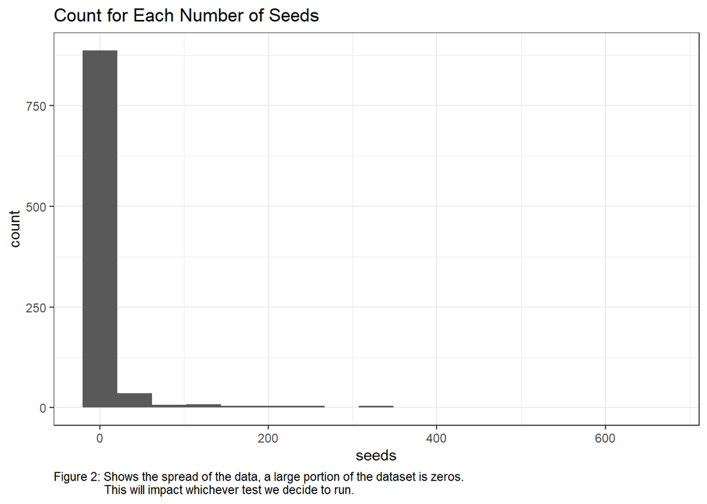

```r
# visualize counts of each number of seeds
ggplot(kang_seed, aes(x = seeds)) +
  geom_histogram(bins = 17) +
  theme_bw() +
  labs(title = "Count for Each Number of Seeds", caption = "Figure 2: Shows the spread of the data, a large portion of the dataset is zeros.
                This will impact whichever test we decide to run.") +
  theme(plot.caption = element_text(hjust = 0))
```

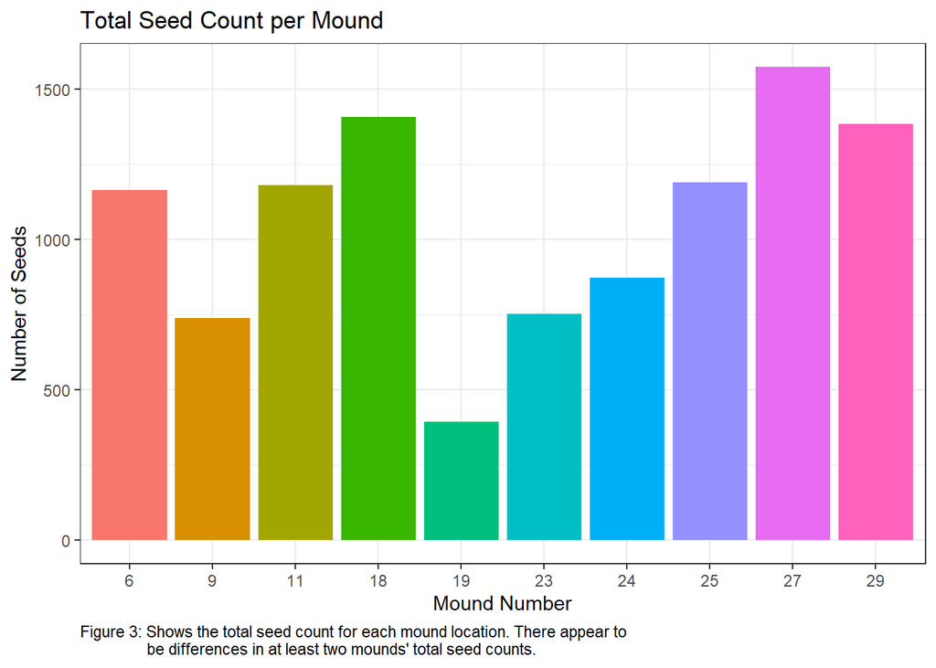

```r
# set up data for bar graph
kang_seed_bar <- kang_seed |>
                 group_by(mnd) |> # group by mound
                 summarise(across(seeds, sum)) |> # sum seed counts for each mound
                 ungroup() # ungroup

# bar graph of total seed counts
ggplot() +
  geom_bar(data = kang_seed_bar, aes(x = mnd, y = seeds, fill = mnd),
           stat = "identity", show.legend = F) +
  theme_bw() +
  labs(x = "Mound Number", y = "Number of Seeds",
       title = "Total Seed Count per Mound", caption = "Figure 3: Shows the total seed count for each mound location. There appear to
                be differences in at least two mounds' total seed counts.") +
  theme(plot.caption = element_text(hjust = 0))
```

**Question: How does total seed number differ between kangaroo rat mound locations?**

#### Choose an Initial Test

We will start by attempting to run an ANOVA test to determine if there is a difference in the total seed count between kangaroo rat mound locations. We chose this test to start because in the methods of the context paper they ran this test to compare the total seed counts.

#### Set Up Initial Hypothesis for ANOVA

$H_0:$ There is no significant difference in seed counts between the kangaroo rat mound locations.  
$H_a:$ There is a significant difference in seed counts between at least two of the kangaroo mound locations.

#### Initial Assumption Checks

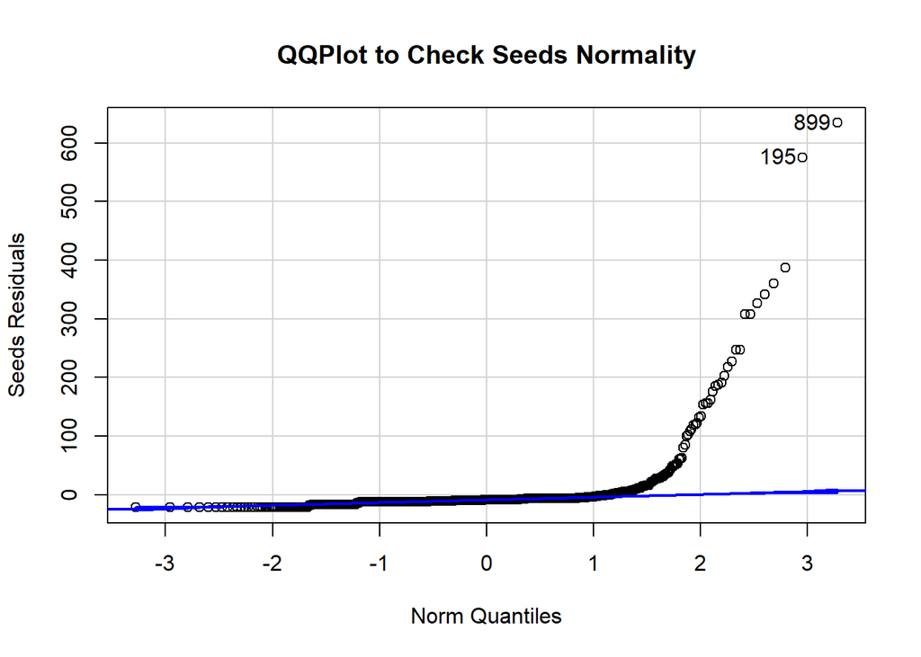

```
## [1] 899 195
```

```r
# make aov object
kang_aov <- aov(seeds ~ mnd, data = kang_seed)

# get resiudals
kang_res <- kang_aov$residuals

# check normality
qqPlot(kang_res, xlab = "Norm Quantiles", ylab = "Seeds Residuals", main = "QQPlot to Check Seeds Normality")
```

The data does not appear to be normal, which we expected because in the context reading they discussed how in their analysis the data was non-normal even after trying transformations. We decided to try a log transformation regardless because this would be the logical next step in this analysis.

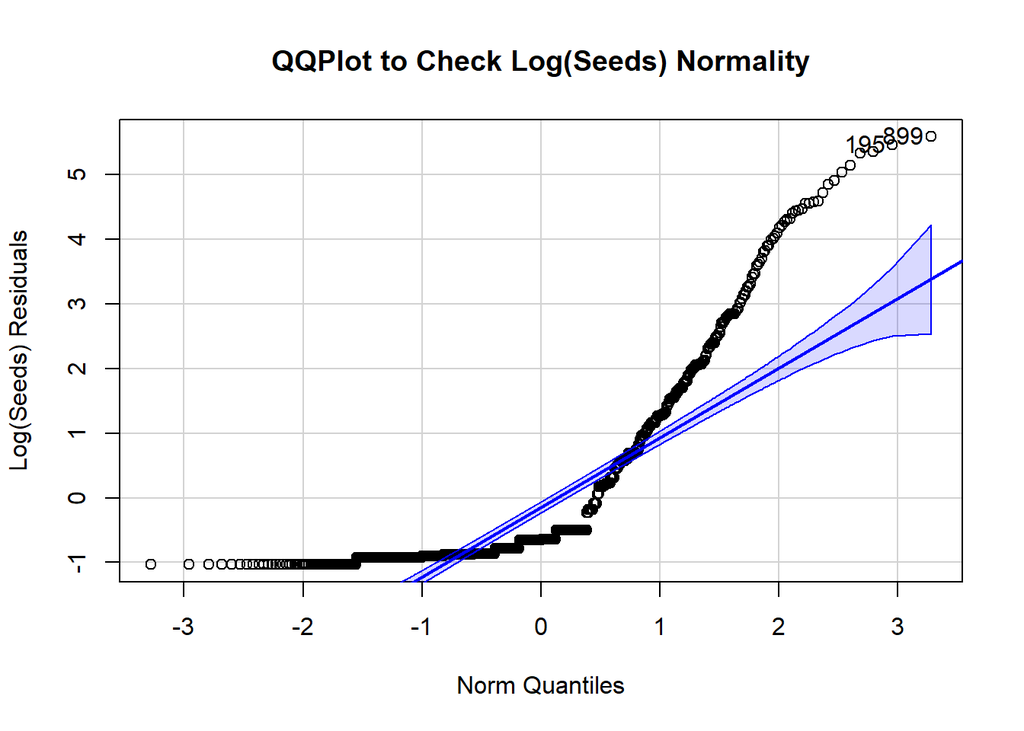

```
## [1] 899 195
```

```r
# transform data
kang_seed_log <- kang_seed |>
                 mutate(seeds = log(seeds + 1))

# make new aov object
kang_log_aov <- aov(seeds ~ mnd, data = kang_seed_log)

# residuals
kang_log_res <- kang_log_aov$residuals

#test normality
qqPlot(kang_log_res, xlab = "Norm Quantiles", ylab = "Log(Seeds) Residuals", main = "QQPlot to Check Log(Seeds) Normality")
```

The data is still non-normal as expected (we stated above that the context paper mentioned how the data is not normal after all transformations).

#### Kruskal-Wallis Test

Due to this we are going to run a Kruskal-Wallis test, for which we meet all assumptions (there are categorical predictor variables, there are independent samples, and each group has at least five observations) and works with count data. This will change our null and alternative hypothesis to be:

$H_0:$ There is no difference in the median total seed number between the kangaroo rat mound locations.  
$H_a:$ There is a difference in at least two kangaroo rat mound locations median total seed number.

```r
# show aov summary
kruskal.test(seeds ~ mnd, data = kang_seed)
```

```
##
##  Kruskal-Wallis rank sum test
##
## data:  seeds by mnd
## Kruskal-Wallis chi-squared = 16.997, df = 9, p-value = 0.04876
```

After running the Kruskal-Wallis test, we reject the null hypothesis. (See results).

### Results

We used a Kruskal-Wallis test to answer the question, **How does the total seed number differ between kangaroo rat mound locations?** The test revealed a p-value of $0.04876$, on $9$ degrees of freedom which shows a significant difference in the median total seed number among at least two kangaroo rat mound locations. This difference in median values provides valuable insights into the total seed variation. The general null hypothesis of the Kruskal-Wallis assumes that there is no difference among the population medians of the groups being compared. Essentially, it tests whether the samples from different groups are likely to come from the same population or if there are systematic differences between the groups. We found that there are systematic differences between the mounds, which implies that the seeds observed in one mound are not randomly distributed among all the mounds but are tied specifically to the individual mound where they were counted.

This provides significant evidence that figure 3 (provided below) is an accurate way of visualizing the difference in total seed count between kangaroo rat mounds.

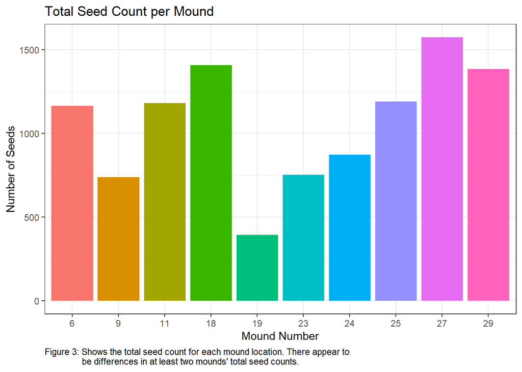

```r
# bar graph of total seed counts
ggplot() +
  geom_bar(data = kang_seed_bar, aes(x = mnd, y = seeds, fill = mnd),
           stat = "identity", show.legend = F) +
  theme_bw() +
  labs(x = "Mound Number", y = "Number of Seeds",
       title = "Total Seed Count per Mound", caption = "Figure 3: Shows the total seed count for each mound location. There appear to
                be differences in at least two mounds' total seed counts.") +
  theme(plot.caption = element_text(hjust = 0))
```

There is an apparent difference in total seed count between mounds shown in this bar plot. Mound 19 has less than 500 seeds while mound 27 has over 1500 total seeds. Mounds 6, 11, 25 have about 1200 seeds and 9 and 23 have around 750 seeds. There seem to similarities for subsets of mounds but as a general consensus there is a significant difference between in total seed number between kangaroo rat mounds.

The precise data follows:

| Mound Number | Number of Seeds |
| --- | --- |
| 6 | 1164 |
| 9 | 739 |
| 11 | 1181 |
| 18 | 1407 |
| 19 | 394 |
| 23 | 752 |
| 24 | 873 |
| 25 | 1190 |
| 27 | 1574 |
| 29 | 1384 |

## Problem 2

### Introduction

Northern peatlands, an important long-term sink of carbon, have recently been affected by drier conditions caused by climate change, leading to a phenomenon called “shrubification” (Moore). In arctic conditions, this shrubification affects “climates feedbacks including land surface albedo and enhanced evapotranspiriation” (Crump). This study makes use of Niwot Ridge data in Colorado to investigate the role of shrubification on plant reproductive success, determined through seed count, as well as the role other factors like species type or the total number of inflorescences (Seaver). This is an important subject to study because it can help see highlight the reproductive success of these shrubs, and it turn see if it will be of concern for albedo and evapotranspiration, which ultimately affects the health of the broader peatland ecosystem. We hypothesize that site type will not be a significant predictor of the measured number of seeds, but species type and total number of inflorescenes will be.

### Methods

#### Loading Data

When loading the data, we only selected for treatment, species, total_inf, num_seeds, and shrub_num, since these are the only variables that we are interested in. As mentioned in the introduction, this data was provided by Micaela M Seaver and the Niwot Ridge LTER.

```r
# loading data
shrub_raw <- read.csv(here("data/shrubstudy_seed.csv"))

shrub_seed <- shrub_raw |>
              dplyr::select(treatment, species, total_inf = total_nr_infl,
                      num_seeds = nr_seeds, shrub_num) |>
              mutate(treatment = as.factor(treatment))
```

#### Data Exploration

##### Missing Data

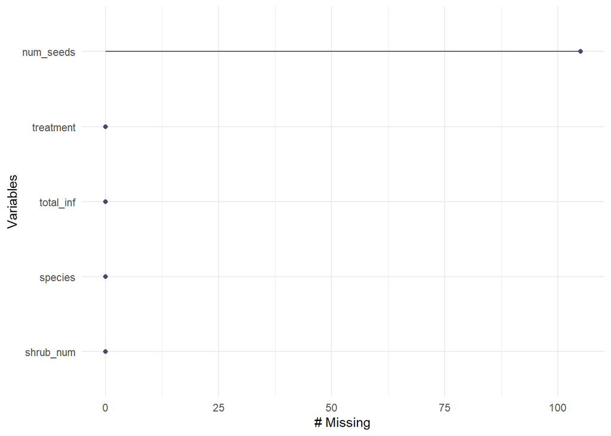

```r
# visualize missing data
gg_miss_var(shrub_seed)
```

This plot shows us that there are a lot of missing values for the num_seeds variable. Moving forward, we will remove these missing values.

##### Skim

```r
skim(shrub_seed)
```

Data summary

| Name | shrub_seed |
| --- | --- |
| Number of rows | 287 |
| Number of columns | 5 |
| _______________________ |  |
| Column type frequency: |  |
| character | 1 |
| factor | 1 |
| numeric | 3 |
| ________________________ |  |
| Group variables | None |

**Variable type: character**

| skim_variable | n_missing | complete_rate | min | max | empty | n_unique | whitespace |
| --- | --- | --- | --- | --- | --- | --- | --- |
| species | 0 | 1 | 6 | 6 | 0 | 19 | 0 |

**Variable type: factor**

| skim_variable | n_missing | complete_rate | ordered | n_unique | top_counts |
| --- | --- | --- | --- | --- | --- |
| treatment | 0 | 1 | FALSE | 2 | con: 174, shr: 113 |

**Variable type: numeric**

| skim_variable | n_missing | complete_rate | mean | sd | p0 | p25 | p50 | p75 | p100 | hist |
| --- | --- | --- | --- | --- | --- | --- | --- | --- | --- | --- |
| total_inf | 0 | 1.00 | 5.15 | 10.45 | 1 | 1.00 | 1 | 5.00 | 117 | ▇▁▁▁▁ |
| num_seeds | 105 | 0.63 | 14.55 | 28.62 | 0 | 1.25 | 5 | 13.75 | 285 | ▇▁▁▁▁ |
| shrub_num | 0 | 1.00 | 29.53 | 16.04 | 5 | 13.00 | 30 | 44.00 | 54 | ▆▁▇▂▅ |

##### Subset Dataset

```r
# filter out missing data
shrub_seed_sub <- shrub_seed |>
                  drop_na(num_seeds)
```

##### Histogram of Counts

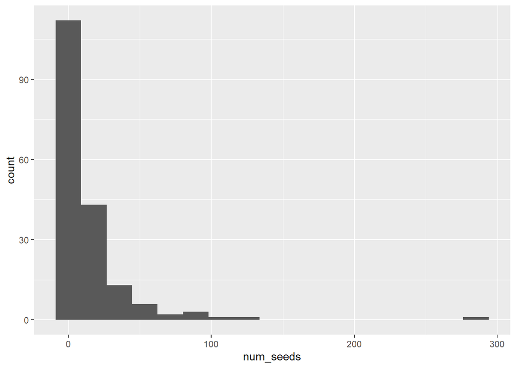

```r
ggplot(shrub_seed_sub, aes(x = num_seeds)) +
  geom_histogram(bins = 17)
```

This histogram shows us that our data includes a lot of zeros.

##### Histogram of Species

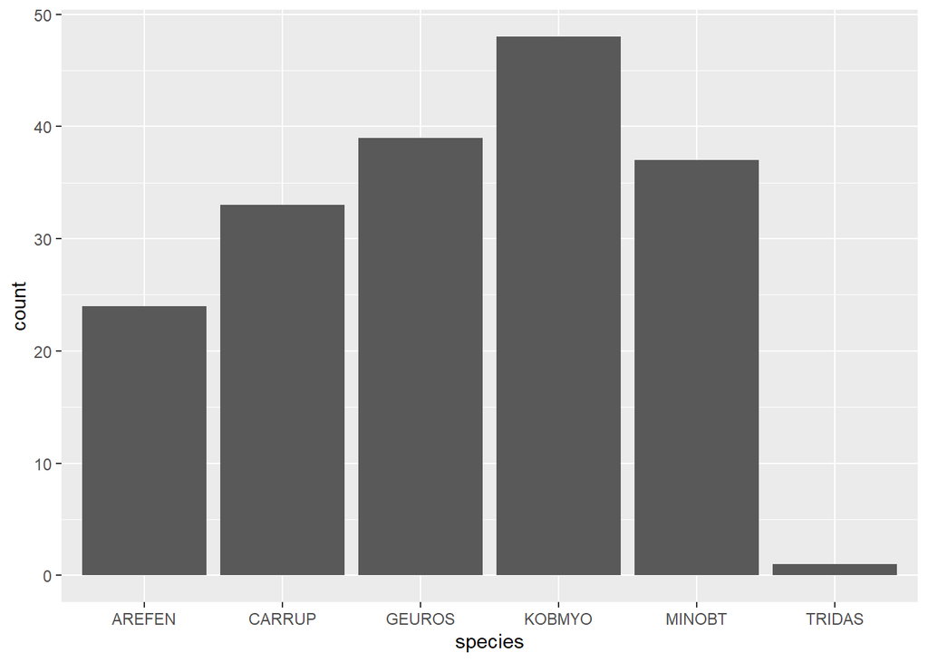

```r
ggplot(shrub_seed_sub, aes(x = species)) +
  geom_bar(stat = 'count')
```

One thing to note from this plot is that TRIDAS appears to only have one sample. Because of this, in the future, the predictions are likely to be all over the place and have a very large confidence interval. In order to increase the interpretability of the following plots, we will remove TRIDAS.

```r
# filter out missing data
shrub_seed_sub <- shrub_seed_sub |>
                  subset(species != "TRIDAS")
```

##### Variable Relationships

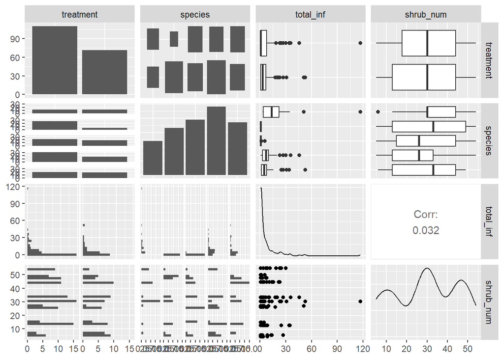

```r
shrub_seed_sub |>
  dplyr::select(!num_seeds) |>
  ggpairs()
```

**Question: How does seed count vary with plot type (shrub or open), plant species, and total number of inflorescences? Is there a simpler model that explains seed count, and if so, what is it?**

#### Null Hypotheses

$H0:$ Plot type, plant species, and total number of inflorescences has no effect on seed count. $H1:$ Plot type, plant species, and total number of inflorescences has a significant effect on seed count.

#### Build Models

In this section, we will be making use of the glmmTMB package to create generalized linear models, and the DHARMA package as a way to check the diagnostics of these models.

```r
# simple models
shrub_null <- lm(num_seeds ~ 1, data = shrub_seed_sub)
shrub_treatment <- lm(num_seeds ~ treatment, data = shrub_seed_sub)
shrub_species <- lm(num_seeds ~ species, data = shrub_seed_sub)
shrub_inf <- lm(num_seeds ~ total_inf, data = shrub_seed_sub)

# linear model, we know this is wrong
shrub_model1 <- lm(num_seeds ~ treatment + species + total_inf, data = shrub_seed_sub)

# generalized linear model with Poisson distribution
shrub_model2 <- glm(num_seeds ~ treatment + species + total_inf, data = shrub_seed_sub, family = "poisson")

# generalized linear model with negative binomial distribution
shrub_model3 <- glmmTMB(num_seeds ~ treatment + species + total_inf, data = shrub_seed_sub, family = "nbinom2")

# generalized linear model with Poisson distribution and random effect of treatment
shrub_model4 <- glmmTMB(num_seeds ~ treatment + species + total_inf + (1|shrub_num),
                          data = shrub_seed_sub, family = "poisson")

# generalized linear model with negative binomial distribution and random effect of treatment
shrub_model5 <- glmmTMB(num_seeds ~ treatment + species + total_inf + (1|shrub_num),
                      data = shrub_seed_sub, family = "nbinom2")
```

Because we are looking at count data, we know that the data is discrete and only has a lower bound. Knowing this, we built a couple different models using the Poisson and Negative Binomial distribution.

##### Model 1

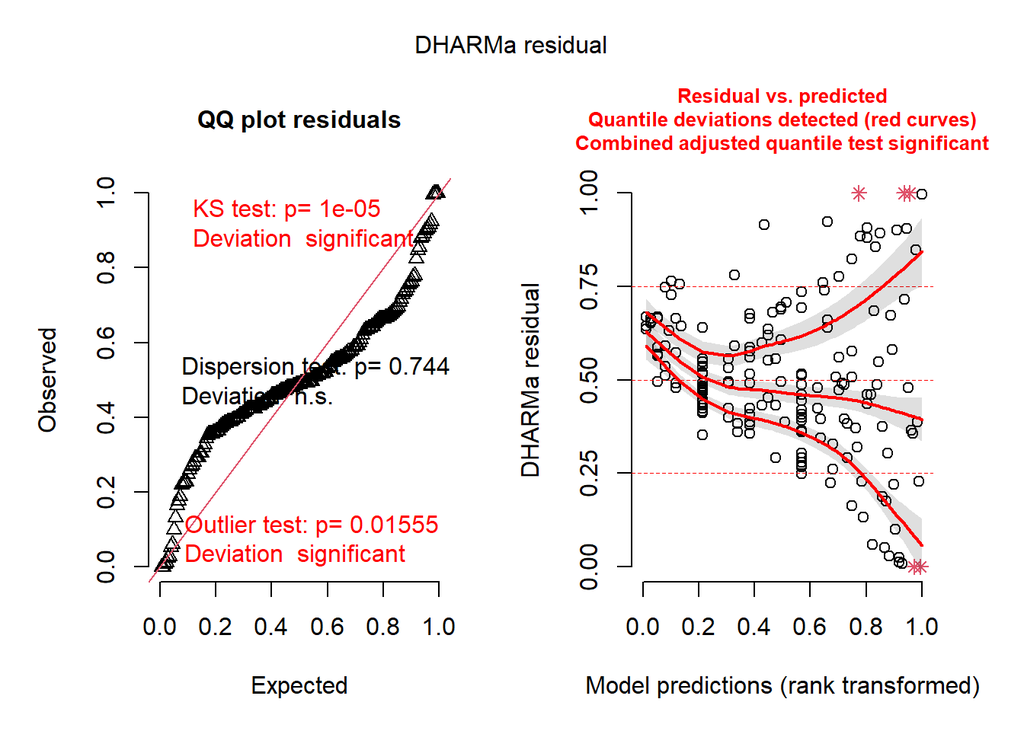

```r
# check diagnostics
simulationOutput_m1 <- simulateResiduals(shrub_model1)

plot(simulationOutput_m1)
```

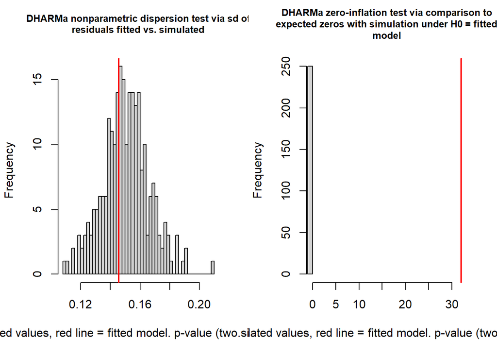

```r
par(mfrow = c(1,2))

testDispersion(simulationOutput_m1)
testZeroInflation(simulationOutput_m1)
```

##### Model 2

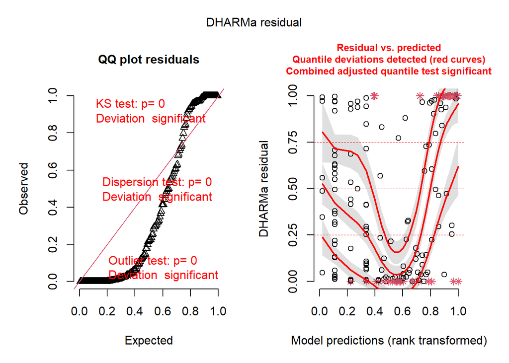

```r
# check diagnostics
simulationOutput_m2 <- simulateResiduals(shrub_model2)

plot(simulationOutput_m2)
```

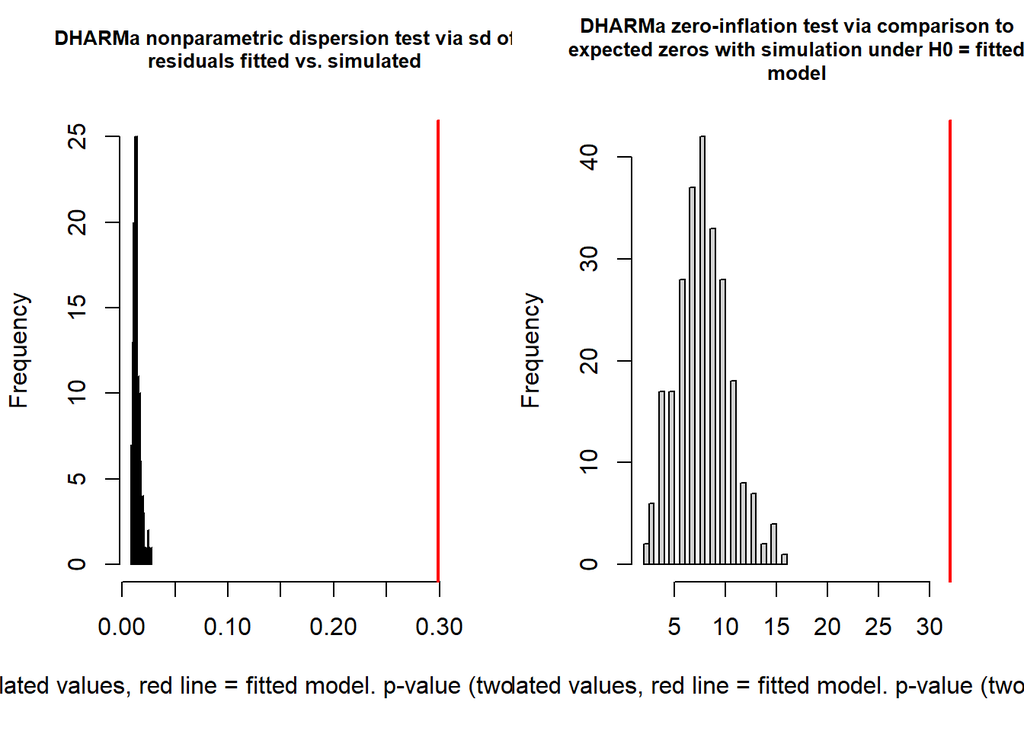

```r
par(mfrow = c(1,2))

testDispersion(simulationOutput_m2)
testZeroInflation(simulationOutput_m2)
```

##### Model 3

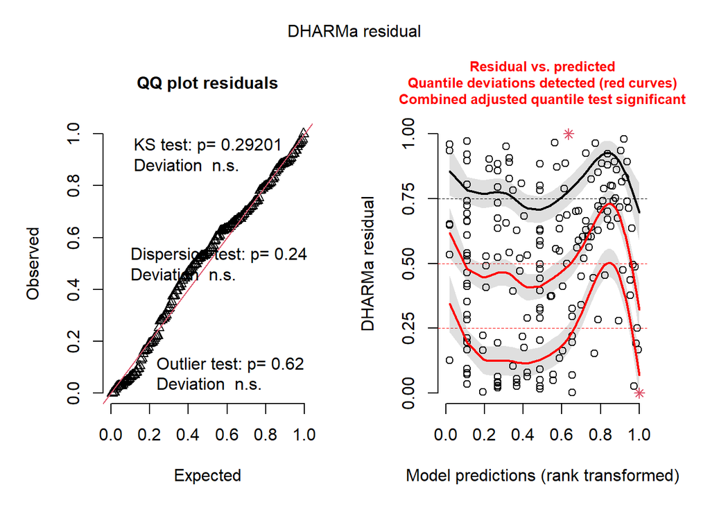

```r
simulationOutput_m3 <- simulateResiduals(shrub_model3)

plot(simulationOutput_m3)
```

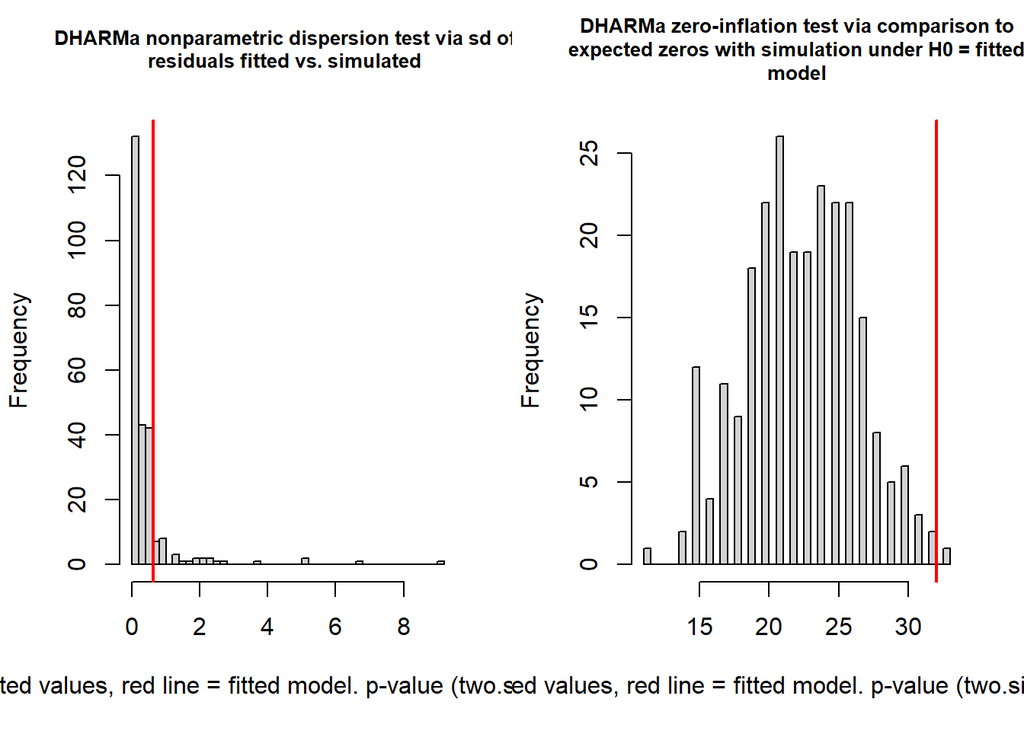

```r
par(mfrow = c(1,2))

testDispersion(simulationOutput_m3)
testZeroInflation(simulationOutput_m3)
```

##### Model 4

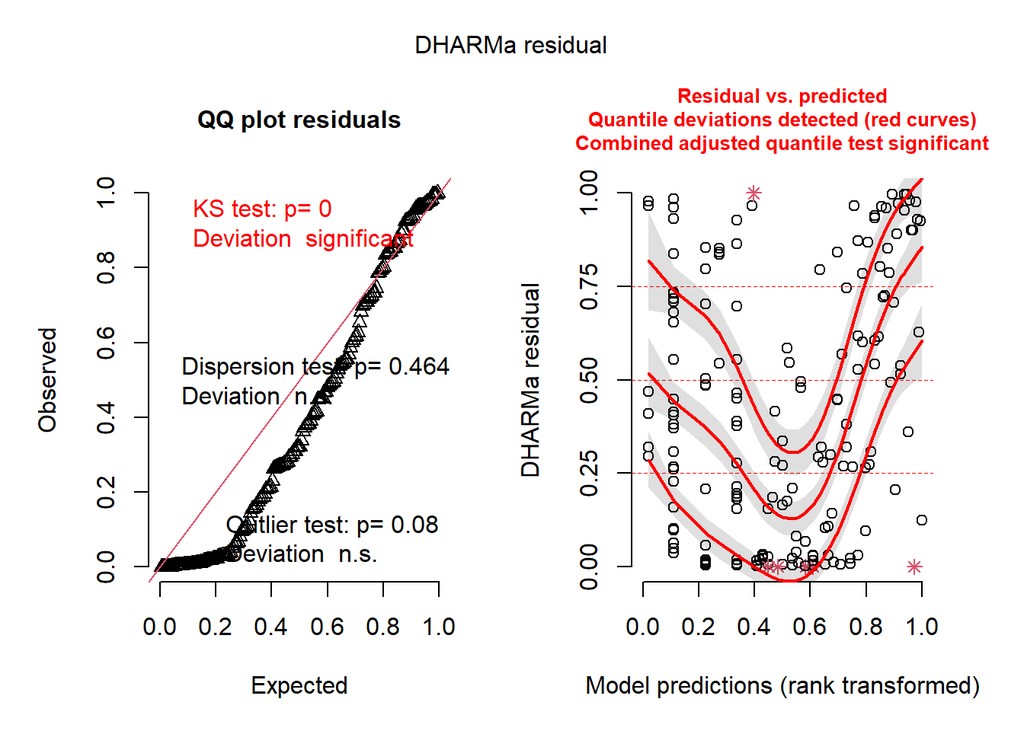

```r
# check diagnostics
simulationOutput_m4 <- simulateResiduals(shrub_model4)

plot(simulationOutput_m4)
```

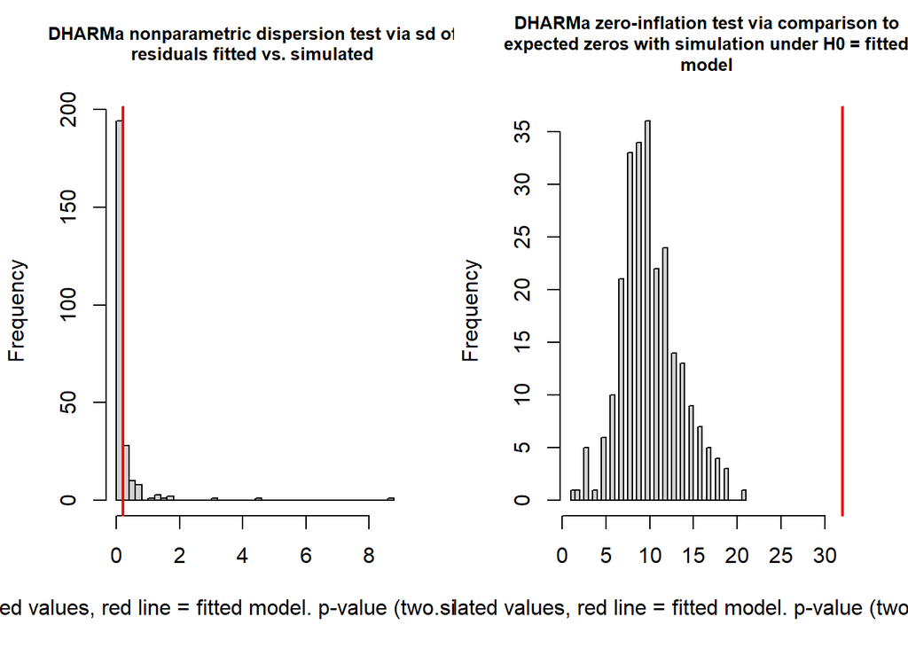

```r
par(mfrow = c(1,2))

testDispersion(simulationOutput_m4)
testZeroInflation(simulationOutput_m4)
```

##### Model 5

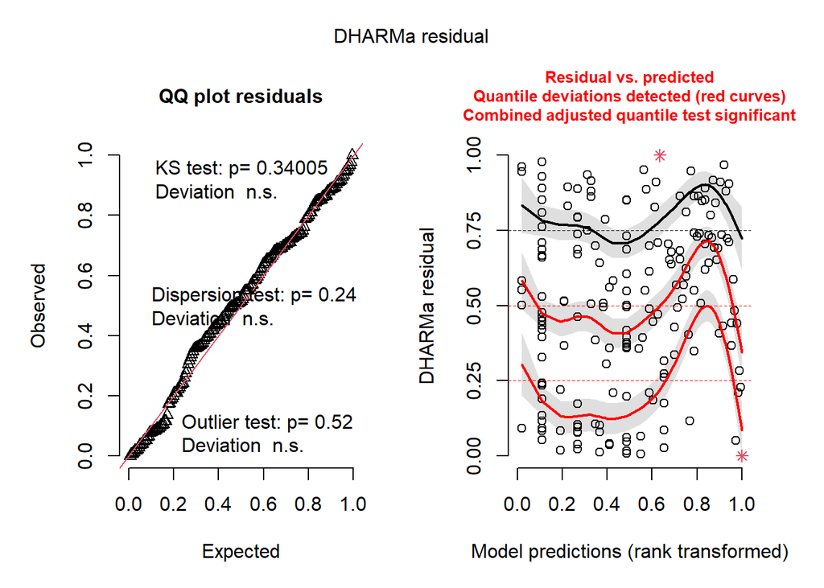

```r
# check diagnostics
simulationOutput_m5 <- simulateResiduals(shrub_model5)

plot(simulationOutput_m5)
```

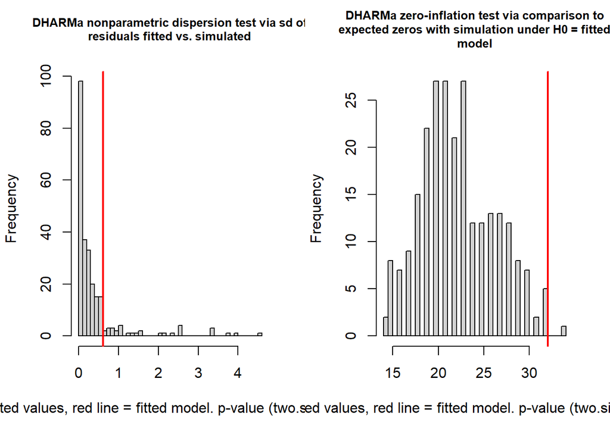

```r
par(mfrow = c(1,2))

testDispersion(simulationOutput_m5)
testZeroInflation(simulationOutput_m5)
```

##### Breakdown of models 1-5:

[output not shown]

Based on the tests above, it appears that either shrub_model3 or shrub_model5 will be the best models because neither are over or under-dispered. However, they do still have some patterns in the residuals, and they appear to be zero-inflated. To further our model, we will create a new model with a zero-inflated term.

##### Model 6

```r
# generalized linear model with negative binomial distribution
shrub_model6 <- glmmTMB(num_seeds ~ treatment + species + total_inf, ziformula = ~1,
                        data = shrub_seed_sub, family = "nbinom2")
```

With the zero-inflated model created, we will now run the necessary diagnostics.

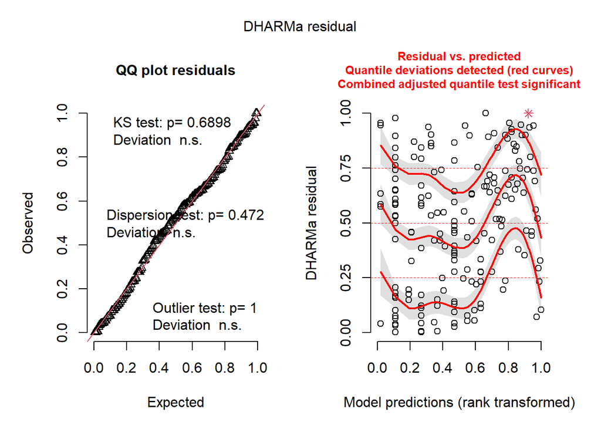

```r
# check diagnostics
simulationOutput_m6 <- simulateResiduals(shrub_model6)

plot(simulationOutput_m6)
```

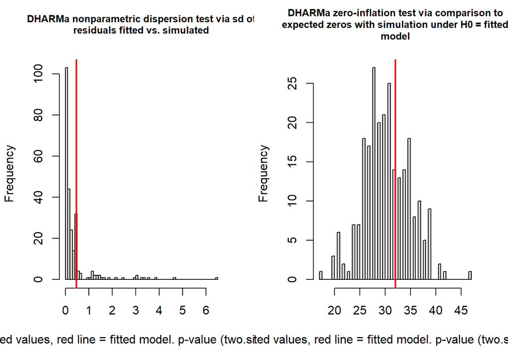

```r
par(mfrow = c(1,2))

testDispersion(simulationOutput_m6)
testZeroInflation(simulationOutput_m6)
```

Based on the above plots, shrub_model6 appears to be our best model. There is no over or underdispersion, and our distribution has about the same number of zeros as our model would predict. There is still some trend in our residuals, but it appears to have been lessened when compared to shrub_model3. We acknowledge this trend in residuals and have decided that isn’t a big cause for concern since the other diagnostics were met.

Moving forward, we will check AICC values to test whether our assumptions about the models are correct.

#### Which distribution to use?

```r
MuMIn::model.sel(shrub_null, shrub_treatment, shrub_inf, shrub_species, shrub_model1, shrub_model2, shrub_model3, shrub_model4, shrub_model5, shrub_model6)
```

```
## Model selection table
##                  (Intr) trt ttl_inf spc cnd((Int)) dsp((Int)) cnd(spc)
## shrub_model6                                 2.156          +        +
## shrub_model3                                 1.917          +        +
## shrub_model5                                 1.915          +        +
## shrub_model1    -2.5670   + 2.15000   +
## shrub_inf       -0.5566     2.09100
## shrub_species   36.2900               +
## shrub_null      14.4300
## shrub_treatment 16.1300   +
## shrub_model4                                 2.488          +        +
## shrub_model2     2.5490   + 0.02989   +
##                 cnd(ttl_inf) cnd(trt) zi((Int)) family   class random df
## shrub_model6         0.06634        +    -2.283 n2(lg) glmmTMB         9
## shrub_model3         0.07502        +           n2(lg) glmmTMB         8
## shrub_model5         0.07505        +           n2(lg) glmmTMB c(s_n)  9
## shrub_model1                                    gs(id)      lm         8
## shrub_inf                                       gs(id)      lm         3
## shrub_species                                   gs(id)      lm         6
## shrub_null                                      gs(id)      lm         2
## shrub_treatment                                 gs(id)      lm         3
## shrub_model4         0.03145        +           ps(lg) glmmTMB c(s_n)  8
## shrub_model2                                    ps(lg)     glm         7
##                    logLik   AICc   delta weight
## shrub_model6     -548.867 1116.8    0.00  0.852
## shrub_model3     -552.052 1120.9    4.15  0.107
## shrub_model5     -551.884 1122.8    6.03  0.042
## shrub_model1     -689.162 1395.2  278.37  0.000
## shrub_inf        -695.263 1396.7  279.88  0.000
## shrub_species    -849.514 1711.5  594.72  0.000
## shrub_null       -863.595 1731.3  614.47  0.000
## shrub_treatment  -863.096 1732.3  615.54  0.000
## shrub_model4    -1055.923 2128.7 1011.90  0.000
## shrub_model2    -1147.380 2309.4 1192.62  0.000
## Abbreviations:
##  family: gs(id) = 'gaussian(identity)', n2(lg) = 'nbinom2(log)',
##          ps(lg) = 'poisson(log)'
## Models ranked by AICc(x)
## Random terms:
##  c(s_n): cond(1 | shrub_num)
```

Additionally, we can see that **our simpler models aren’t performing as well compared to our more complex models.**

Next, we will look closer at our model: shrub_model6.

#### Model Summary

```r
# summary
summary(shrub_model6)
```

```
##  Family: nbinom2  ( log )
## Formula:          num_seeds ~ treatment + species + total_inf
## Zero inflation:             ~1
## Data: shrub_seed_sub
##
##      AIC      BIC   logLik deviance df.resid
##   1115.7   1144.5   -548.9   1097.7      172
##
##
## Dispersion parameter for nbinom2 family (): 2.18
##
## Conditional model:
##                 Estimate Std. Error z value Pr(>|z|)
## (Intercept)     2.155988   0.212883  10.128  < 2e-16 ***
## treatmentshrub -0.299250   0.131830  -2.270   0.0232 *
## speciesCARRUP  -1.718777   0.281984  -6.095 1.09e-09 ***
## speciesGEUROS  -0.238970   0.242542  -0.985   0.3245
## speciesKOBMYO   0.046928   0.201021   0.233   0.8154
## speciesMINOBT  -0.416711   0.212101  -1.965   0.0495 *
## total_inf       0.066343   0.007516   8.827  < 2e-16 ***
## ---
## Signif. codes:  0 '***' 0.001 '**' 0.01 '*' 0.05 '.' 0.1 ' ' 1
##
## Zero-inflation model:
##             Estimate Std. Error z value Pr(>|z|)
## (Intercept)  -2.2827     0.3991  -5.719 1.07e-08 ***
## ---
## Signif. codes:  0 '***' 0.001 '**' 0.01 '*' 0.05 '.' 0.1 ' ' 1
```

```r
# confidence intervals
confint(shrub_model6)
```

```
##                          2.5 %       97.5 %    Estimate
## cond.(Intercept)     1.7387449  2.573230737  2.15598779
## cond.treatmentshrub -0.5576313 -0.040868234 -0.29924976
## cond.speciesCARRUP  -2.2714556 -1.166099126 -1.71877737
## cond.speciesGEUROS  -0.7143430  0.236403207 -0.23896992
## cond.speciesKOBMYO  -0.3470654  0.440921896  0.04692825
## cond.speciesMINOBT  -0.8324210 -0.001001714 -0.41671134
## cond.total_inf       0.0516118  0.081073969  0.06634289
## zi.(Intercept)      -3.0649895 -1.500469125 -2.28272929
```

```r
# adjusted R2
r.squaredGLMM(shrub_model6)
```

```
##                 R2m       R2c
## delta     0.7225478 0.7225478
## lognormal 0.7643760 0.7643760
## trigamma  0.6655456 0.6655456
```

### Results

#### Table Format

```r
# model object in table
shrub_model6 |>
  as_flextable() |>
  set_caption(
    as_paragraph(
      as_chunk("Table 1: This table displays what we studied earlier in the summary,
      just in an easier to digest format.


               ",
               props = fp_text_default(font.family = "Arial"))
    ),

    word_stylename = "Table Caption"
  )
```

Table 1: This table displays what we studied earlier in the summary, just in an easier to digest format.

|  |  | Estimate | Standard Error |  | statistic | p-value |  |
| --- | --- | --- | --- | --- | --- | --- | --- |
| Fixed effects |  |  |  |  |  |  |  |
|  | (Intercept) | 2.156 | 0.213 |  | 10.128 | 0.0000 | *** |
|  | treatmentshrub | -0.299 | 0.132 |  | -2.270 | 0.0232 |  |
|  | speciesCARRUP | -1.719 | 0.282 |  | -6.095 | 0.0000 | *** |
|  | speciesGEUROS | -0.239 | 0.243 |  | -0.985 | 0.3245 |  |
|  | speciesKOBMYO | 0.047 | 0.201 |  | 0.233 | 0.8154 |  |
|  | speciesMINOBT | -0.417 | 0.212 |  | -1.965 | 0.0495 |  |
|  | total_inf | 0.066 | 0.008 |  | 8.827 | 0.0000 | *** |
|  | (Intercept) | -2.283 | 0.399 |  | -5.719 | 0.0000 | *** |

Signif. codes: 0 <= '***' < 0.001 < '**' < 0.01 < '*' < 0.05  
square root of the estimated residual variance: 2.2  
data's log-likelihood under the model: -548.9  
Akaike Information Criterion: 1,115.7  
Bayesian Information Criterion: 1,144.5

#### Visualization

```r
# Compute predictions
predictions <- ggpredict(shrub_model6, terms = c("treatment", "species", "total_inf"))
```

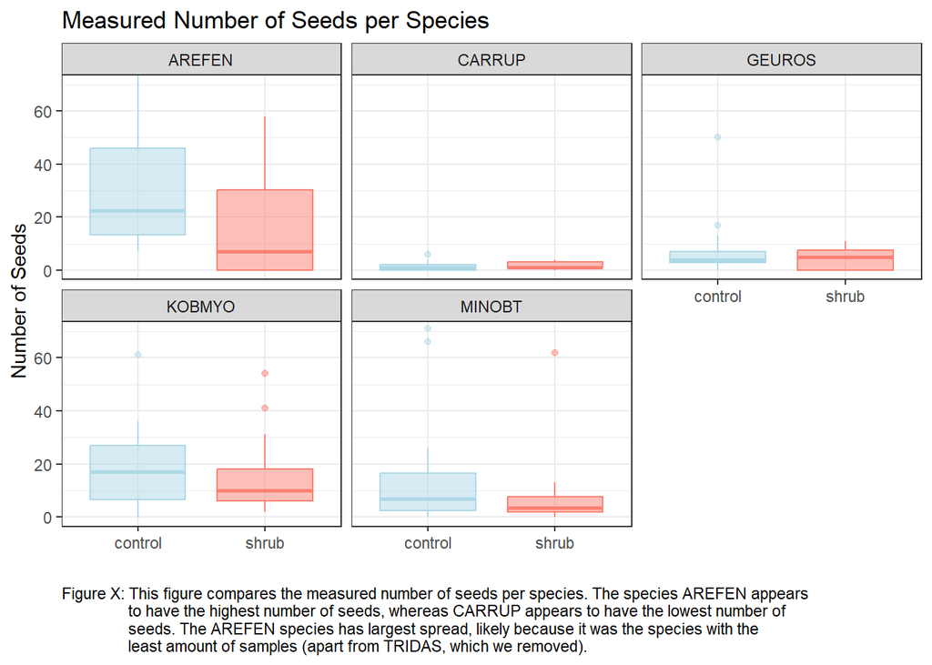

```r
# Plot showing seed differences by Species in the ACTUAL DATA
ggplot(shrub_seed_sub, aes(x = treatment, y = num_seeds, fill = treatment)) +
  geom_boxplot(aes(color = treatment), alpha = 0.5) +
  facet_wrap(~ species) +
  scale_fill_manual(values = c("control" = "lightblue", "shrub" = "salmon")) +
  scale_color_manual(values = c("control" = "lightblue", "shrub" = "salmon")) +
  theme_bw() +
  labs(
    x = "",
    y = "Number of Seeds",
    title = "Measured Number of Seeds per Species",
    caption = "Figure X: This figure compares the measured number of seeds per species. The species AREFEN appears
                to have the highest number of seeds, whereas CARRUP appears to have the lowest number of
                seeds. The AREFEN species has largest spread, likely because it was the species with the
                least amount of samples (apart from TRIDAS, which we removed)."
  ) +
  coord_cartesian(ylim = c(0, 70)) +
  theme(plot.caption = element_text(hjust=0),
        legend.position = 'none')
```

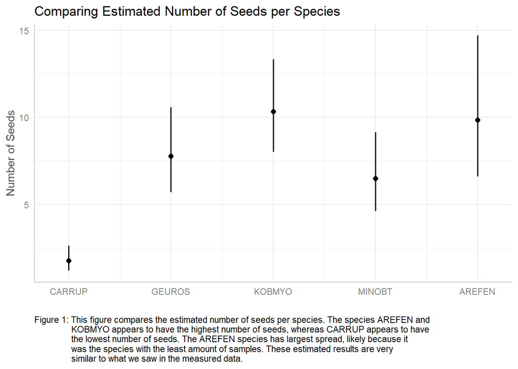

```r
# Predictions
pred <- ggpredict(shrub_model6, terms = "species", back.transform = TRUE)

# Plot showing seed differences by Species
plot(pred) +
  labs(
    x = "",
    y = "Number of Seeds",
    title = "Comparing Estimated Number of Seeds per Species",
    caption = "Figure 1: This figure compares the estimated number of seeds per species. The species AREFEN and
                KOBMYO appears to have the highest number of seeds, whereas CARRUP appears to have
                the lowest number of seeds. The AREFEN species has largest spread, likely because it
                was the species with the least amount of samples. These estimated results are very
                similar to what we saw in the measured data."
  ) +
  theme(plot.caption = element_text(hjust=0))
```